# R Notebook

Maximum Likelihood Estimate (MLE)

- involves treating the problem as an optimisation or search problem, where we seek a set of parameters that results in the best fit for the joint probability of the data sample ($X$).
- First defining parameter theta that defines
  - both the choice of the probability density function
  - parameters of that distribution

In MLE, we wish to maximise the probability of observing the data from the joint probability distribution given a specific probability distribution and its parameters, stated formally as:

$$P(X | theta) \text{ or } P(X; theta) \text{ or } P(x_{1}, x_{2}, x_{3}, \dots, x_{n} ; theta)$$

Resulting conditional probability is then written as `L()` to denote the likelihood function. For example, $L(X; theta)$

We want to maximise the value as such, $\text{maximise } L(X; theta)$

MLE asks the question, **“Given the data that we observe (our sample), what are the model parameters that maximize the likelihood of the observed data occurring?”**

Suppose we have a random sample $X_{1}, X_{2}, X_{3}, \dots, X_{n}$ for which the probability density (**or mass**) function of each $X_{i} is f(x_{i}; \theta)$.

Then, the joint probability mass (or **density**) function of $X_{1}, X_{2}, X_{3}, \dots, X_{n}$ which is called $L(\theta)$ is

$$L(\theta) = P(X_{1} = x_{1}, X_{2} = x_{2}, \dots, X_{n} = x_{n}) = f(x_{1}; \theta) \cdot f(x_{2}; \theta) \dots, f(x_{n}; \theta) = \prod_{i=1}^{n} f(x{i}; \theta)$$

https://online.stat.psu.edu/stat415/lesson/1/1.2

Challenge of MLE is that as the probability densities are smaller than 1, the value of L(x) can become extremely small as the sample grows. For example

```r
set.seed(2017)
prod(dnorm(rnorm(50)))
```

```
[1] 0.00000000000000000000000000000000763147
```

When the variance of the distribution is small it is also possible to have probability densities higher than one. In this case, the likelihood function will grow to very large values. For example, for a Normal distribution with standard deviation of 0.1 we get:

```r
prod(dnorm(rnorm(100, sd = 0.1), sd = 0.1))
```

```
[1] 1793307677408281028271794282512932405248
```

```r
mean(x$x)
```

```
[1] 50.82489
```

```r
sd(x$x)
```

```
[1] 10.65909
```

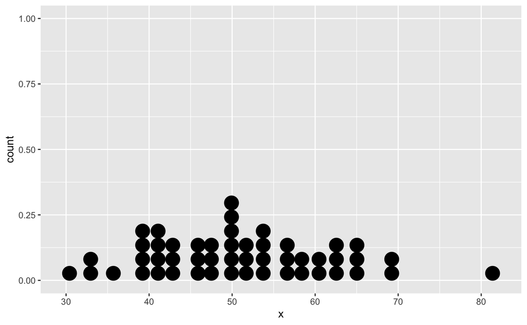

```r
x %>%
  ggplot(aes(x = x)) +
  geom_dotplot()
```

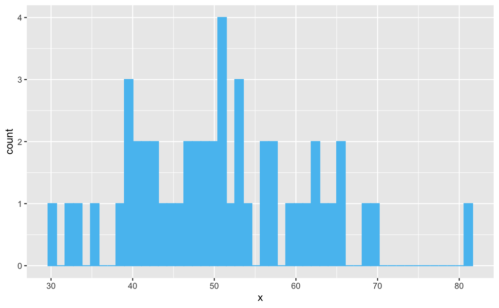

```r
set.seed(2017)
data.frame(x = rnorm(50,50,10)) %>%
  ggplot(aes(x = x)) +
  geom_histogram(bins = 50)
```

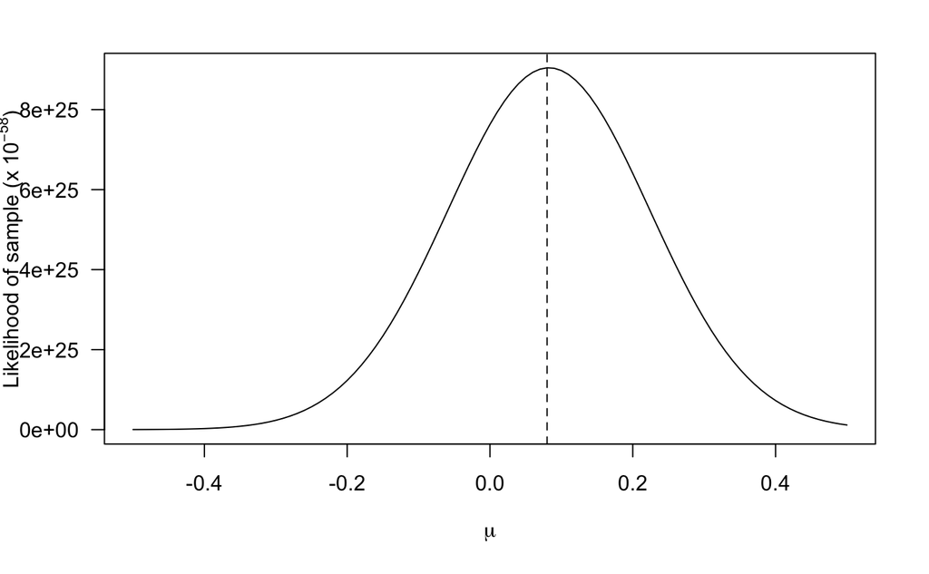

```r
Lfun = function(mu) sapply(mu, function(x) prod(dnorm(x = sample, mean = x)))
x = seq(-0.5,0.5,0.01)
Lx = sapply(x, Lfun)
plot(x, Lx*1e58, t = "l", xlab = expression(mu), ylab = expression("Likelihood of sample (x"~10^{-58}*")"), las = 1)
abline(v = x[which.max(Lx)], lty = 2)
```

whereas for the log-likelihood it becomes:

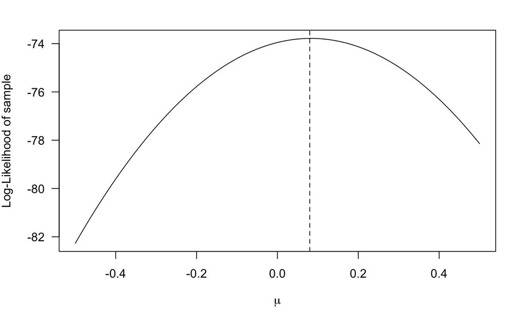

```r
plot(x,log(Lx), t = "l", xlab = expression(mu), ylab = expression("Log-Likelihood of sample"), las = 1)
abline(v = x[which.max(Lx)], lty = 2)
```

Although the shapes of the curves are different, the maximum occurs for the same value of $\mu$. Note that there is nothing special about the natural logarithm: we could have taken the logarithm with base 10 or any other base. But it is customary to use the natural logarithm as some important probability density functions are exponential functions (e.g. the Normal distribution, see above), so taking the natural logarithm makes mathematical analyses easier.

The *likelihood*—more precisely, the *likelihood function*—is a function that represents how likely it is to obtain a certain set of observations from a given model. We’re considering the set of observations as fixed—they’ve happened, they’re in the past—and now we’re considering under which set of model parameters we would be most likely to observe them.

### Coin Flip Example

Consider an example. Let’s say we flipped a coin $100$ times and observed $52$ heads and $48$ tails. We want to come up with a model that will predict the number of heads we’ll get if we kept flipping another $100$ times.

Formalising the problem a bit, let’s denote the random variable $X$ as being the number of heads obtained from $100$ coin flips. Given that:

- there are only two possible outcomes (heads and tails),
- there’s a fixed number of “trials” ($100$ coin flips), and that
- there’s a fixed probability of “success” (ie getting a heads),

we might reasonably suggest that the situation could be modelled using a *binomial distribution.*

We can use R to set up the problem as follows:

```r
# I don't know about you but I'm feeling
set.seed(22)

# Generate an outcome, ie number of heads obtained, assuming a fair coin was used for the 100 flips
heads <- rbinom(1,100,0.5)

heads
```

```
[1] 52
```

This probability is our likelihood function—it allows us to calculate the probability, ie how likely it is, of that our set of data being observed given a probability of heads $p$.

#### Find the $p$ that maximises this likelihood function

```r
# To illustrate, let's find the likelihood of obtaining these results if p was 0.6—that is, if our coin was
# biased in such a way to show heads 60% of the time.
biased_prob <- 0.6

# Explicit calculation
choose(100,52)*(biased_prob**52)*(1-biased_prob)**48
```

```
[1] 0.02148776
```

```r
# 0.0214877567069514
```

```r
# Using R's dbinom function (density function for a given binomial distribution)
dbinom(heads,100,biased_prob)
```

```
[1] 0.02148776
```

Function that will calculat the likelihood function for a given p

```r
likelihood <- function(p){
  dbinom(heads, 100, p)
}

# Test that our function gives the same result as in our earlier example
likelihood(biased_prob)
```

```
[1] 0.02148776
```

*nlm* function, which stands for non-linear minimisation

*maximising a function is equivalent to minimising the function multiplied by minus one*

```r
negative_likelihood <- function(p){
  dbinom(heads, 100, p)*-1
}

# Test that our function is behaving as expected
negative_likelihood(biased_prob)
```

```
[1] -0.02148776
```

Finding MLE for $p$

```r
nlm(negative_likelihood,0.5,stepmax=0.5)
```

```
$minimum
[1] -0.07965256

$estimate
[1] 0.5199995

$gradient
[1] -0.00000000002775558

$code
[1] 1

$iterations
[1] 4
```

The `nlm()` function has returned some information about its quest to find the MLE estimate of $p$.

- minimum denotes the minimum value of the negative likelihood that was found—so the maximum likelihood is just this value multiplied by minus one, e.g. $0.07965...$;
- estimate is our MLE estimate of $p$;
- gradient is the gradient of the likelihood function in the vicinity of our estimate of $p$—we would expect this to be very close to zero for a successful estimate;
- code explains to use why the minimisation algorithm was terminated—a value of 1 indicates that the minimisation is likely to have been successful; and
- iterations tells us the number of iterations that `nlm()` had to go through to obtain this optimal value of the parameter.